# Project 2 — Data Tidying: Electricity Production by Country

Author

Aniss Sahraoui

Published

October 10, 2026

```r
library(tidyverse)
library(knitr)

# Shared styling, used across all three Project 2 reports
accent   <- "#2a78d6"
accent_2 <- "#eb6834"
theme_p2 <- theme_minimal(base_size = 12) +
  theme(panel.grid.minor = element_blank(), plot.title.position = "plot")
```

# Data Source

This dataset comes from the Discussion 5A post **“Total Energy Production by Country”** by Ellie Wilser. The post uses Wikipedia’s list of countries by electricity production and explains the problem with it:

> “The data is arranged with each country as a row and columns representing the different types of electricity generation methods. This data is untidy because of the multi-level headers, such as coal and gas being grouped together under fossil fuels.”

The post then asks two questions:

> “1. What country is the most sustainable? (Highest amount of renewables? Lowest amount of fossils? Highest percentage of renewables?) 2. Can the countries be grouped or clustered based on their primary energy type?”

**Source:** Wikipedia, *List of countries by electricity production* (https://en.wikipedia.org/wiki/List_of_countries_by_electricity_production), which in turn draws on Ember’s electricity data.

**How it was obtained:** I scraped the first table on that page and wrote it to `data/electricity_production_wide.csv`, preserving the wide layout. The page uses a two-row header, which a CSV cannot hold directly, so I joined the two levels with a pipe: the column under *Fossil fuels → Coal* became `Fossil fuels | Coal`. No information is lost, the file stays untidy in exactly the way the post describes, and the tidying step has to split those names apart.

# Data Structure Before Tidying

```r
raw_power <- read_csv(
  "https://raw.githubusercontent.com/AnissSahraoui/DATA607/main/Week6/data/electricity_production_wide.csv",
  show_col_types = FALSE
)

dim(raw_power)
```

```
[1] 216  12
```

```r
names(raw_power)
```

```
 [1] "Location"               "Total (TWh)"            "Fossil fuels | Coal"
 [4] "Fossil fuels | Gas"     "Fossil fuels | Other"   "Nuclear | Nuclear"
 [7] "Renewables | Hydro"     "Renewables | Wind"      "Renewables | Solar"
[10] "Renewables | Bioenergy" "Renewables | Other"     "Year"
```

```r
raw_power |> slice_head(n = 5) |> select(1:7)
```

```
# A tibble: 5 × 7
  Location      `Total (TWh)` `Fossil fuels | Coal` `Fossil fuels | Gas`
  <chr>                 <dbl>                 <dbl>                <dbl>
1 World                31747.                10491.               6904.
2 China                10580.                 5773.                318.
3 United States         4520.                  737.               1807.
4 India                 2082.                 1474.                 48.5
5 Russia                1193.                  220.                533.
# ℹ 3 more variables: `Fossil fuels | Other` <dbl>, `Nuclear | Nuclear` <dbl>,
#   `Renewables | Hydro` <dbl>
```

There is also a row for `World`, which is the sum of the country rows rather than a country.

```r
tibble(
  column = names(raw_power),
  type   = map_chr(raw_power, ~ class(.x)[1])
) |>
  slice_head(n = 6) |>
  kable()
```

| column | type |
| --- | --- |
| Location | character |
| Total (TWh) | numeric |
| Fossil fuels \| Coal | numeric |
| Fossil fuels \| Gas | numeric |
| Fossil fuels \| Other | numeric |
| Nuclear \| Nuclear | numeric |

# Transformation Steps

```r
power <- raw_power |>
  # 1. Reshape wide to long. names_sep splits each "Group | Source" heading into
  #    two columns, which recovers the page's two-level header as real variables.
  pivot_longer(
    cols      = contains("|"),
    names_to  = c("energy_group", "source"),
    names_sep = " \\| ",
    values_to = "generation_twh"
  ) |>
  # 2. Rename the remaining columns to snake_case for consistency.
  rename(
    country       = Location,
    country_total = `Total (TWh)`,
    year          = Year
  ) |>
  # 3. Convert text to numbers by stripping the thousands separators.
  mutate(
    across(c(generation_twh, country_total),
           ~ as.numeric(str_remove_all(as.character(.x), ","))),
    year = as.integer(year),
    # 4. Normalize an ambiguous label: "Other" appears under BOTH groups, meaning
    #    oil-fired plants in one case and geothermal etc. in the other. Left alone,
    #    grouping by source would silently merge two different things.
    source = case_when(
      energy_group == "Fossil fuels" & source == "Other" ~ "Other fossil",
      energy_group == "Renewables"   & source == "Other" ~ "Other renewable",
      TRUE                                               ~ source
    )
  )

glimpse(power)
```

```
Rows: 1,944
Columns: 6
$ country        <chr> "World", "World", "World", "World", "World", "World", "…
$ country_total  <dbl> 31746.92, 31746.92, 31746.92, 31746.92, 31746.92, 31746…
$ year           <int> 2025, 2025, 2025, 2025, 2025, 2025, 2025, 2025, 2025, 2…
$ energy_group   <chr> "Fossil fuels", "Fossil fuels", "Fossil fuels", "Nuclea…
$ source         <chr> "Coal", "Gas", "Other fossil", "Nuclear", "Hydro", "Win…
$ generation_twh <dbl> 10491.47, 6903.64, 823.92, 2813.09, 4433.08, 2711.33, 2…
```

**Missing values.** Blank cells are common in this table:

```r
power |>
  summarise(
    rows            = n(),
    missing_values  = sum(is.na(generation_twh)),
    pct_missing     = round(100 * mean(is.na(generation_twh)), 1)
  )
```

```
# A tibble: 1 × 3
   rows missing_values pct_missing
  <int>          <int>       <dbl>
1  1944            914          47
```

On Wikipedia a blank cell means the country generates **no measurable electricity from that source**, not that the value is unknown: a country with no nuclear plants simply has an empty nuclear cell. The country totals confirm this reading, since they equal the sum of the non-blank entries. I therefore **replace blanks with 0 rather than dropping them**, because dropping the rows would make countries look as though they had fewer sources rather than zero output from some.

```r
power <- power |> mutate(generation_twh = replace_na(generation_twh, 0))

# Verify the decision: do the per-source values now add up to the published total?
power |>
  group_by(country, country_total) |>
  summarise(sum_of_sources = sum(generation_twh), .groups = "drop") |>
  mutate(difference = abs(sum_of_sources - country_total)) |>
  summarise(
    countries       = n(),
    max_difference  = round(max(difference, na.rm = TRUE), 2),
    within_1_twh    = sum(difference < 1, na.rm = TRUE)
  ) |>
  kable()
```

| countries | max_difference | within_1_twh |
| --- | --- | --- |
| 216 | 0.28 | 216 |

The sources add to the published total for every row, which confirms that blank means zero.

**Separating countries from the world total.** The `World` row is an aggregate, so including it in a country ranking would be double counting. Two countries report zero generation entirely, so they carry no mix to analyse and are excluded from percentage questions.

```r
world <- power |> filter(country == "World")

countries <- power |>
  filter(country != "World") |>
  group_by(country) |>
  mutate(total_generation = sum(generation_twh)) |>
  ungroup() |>
  filter(total_generation > 0)

tibble(
  raw_rows            = nrow(raw_power),
  world_rows_removed  = 1,
  zero_output_removed = n_distinct(power$country) - 1 - n_distinct(countries$country),
  countries_analysed  = n_distinct(countries$country)
) |>
  kable()
```

| raw_rows | world_rows_removed | zero_output_removed | countries_analysed |
| --- | --- | --- | --- |
| 216 | 1 | 2 | 213 |

# Analytical Methods

The post asks about sustainability and about grouping countries by primary energy type. I answer them as follows:

- **Sustainability** has three readings in the post, and they give different winners, so I report all three: the largest *absolute* renewable output, the highest *share* of renewables, and the share among countries large enough for the comparison to be meaningful (over 100 TWh).
- **Grouping** uses each country’s **dominant source**: the single source producing the most electricity there. This is a deterministic classification rather than a clustering algorithm, so it needs no random seed and the group labels mean something concrete.

## The world mix, for reference

```r
world |>
  mutate(share = 100 * generation_twh / country_total) |>
  arrange(desc(share)) |>
  transmute(`Energy group` = energy_group, Source = source,
            `TWh` = round(generation_twh),
            `Share of world (%)` = round(share, 1)) |>
  kable()
```

| Energy group | Source | TWh | Share of world (%) |
| --- | --- | --- | --- |
| Fossil fuels | Coal | 10491 | 33.0 |
| Fossil fuels | Gas | 6904 | 21.7 |
| Renewables | Hydro | 4433 | 14.0 |
| Nuclear | Nuclear | 2813 | 8.9 |
| Renewables | Solar | 2778 | 8.8 |
| Renewables | Wind | 2711 | 8.5 |
| Fossil fuels | Other fossil | 824 | 2.6 |
| Renewables | Bioenergy | 703 | 2.2 |
| Renewables | Other renewable | 89 | 0.3 |

## Sustainability, three ways

```r
mix <- countries |>
  group_by(country, total_generation) |>
  summarise(
    renewable_twh = sum(generation_twh[energy_group == "Renewables"]),
    fossil_twh    = sum(generation_twh[energy_group == "Fossil fuels"]),
    nuclear_twh   = sum(generation_twh[energy_group == "Nuclear"]),
    .groups = "drop"
  ) |>
  mutate(
    pct_renewable = 100 * renewable_twh / total_generation,
    pct_fossil    = 100 * fossil_twh / total_generation
  )

mix |>
  slice_max(renewable_twh, n = 5) |>
  transmute(Country = country,
            `Renewable TWh` = round(renewable_twh),
            `Total TWh` = round(total_generation),
            `Renewable share (%)` = round(pct_renewable, 1)) |>
  kable(caption = "Largest renewable output in absolute terms")
```

Largest renewable output in absolute terms

| Country | Renewable TWh | Total TWh | Renewable share (%) |
| --- | --- | --- | --- |
| China | 3913 | 10580 | 37.0 |
| United States | 1159 | 4520 | 25.6 |
| Brazil | 650 | 751 | 86.6 |
| India | 501 | 2082 | 24.1 |
| Canada | 417 | 652 | 63.9 |

```r
mix |>
  filter(pct_renewable >= 99.5) |>
  arrange(desc(total_generation)) |>
  transmute(Country = country,
            `Total TWh` = round(total_generation, 1),
            `Renewable share (%)` = round(pct_renewable, 1)) |>
  kable(caption = "Countries generating essentially all electricity from renewables")
```

Countries generating essentially all electricity from renewables

| Country | Total TWh | Renewable share (%) |
| --- | --- | --- |
| Paraguay | 45.4 | 100 |
| Ethiopia | 33.4 | 100 |
| Iceland | 19.0 | 100 |
| DR Congo | 15.9 | 100 |
| Costa Rica | 12.8 | 100 |
| Nepal | 11.1 | 100 |
| Bhutan | 11.0 | 100 |
| Albania | 8.3 | 100 |
| Central African Republic | 0.1 | 100 |

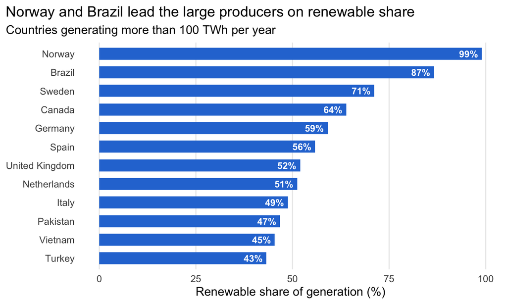

Figure 1: Renewable share of generation for countries producing more than 100 TWh. Only large producers are shown, because a country generating a few TWh can reach 100% with a single dam.

```r
large <- mix |> filter(total_generation > 100)

large |>
  slice_max(pct_renewable, n = 12) |>
  mutate(country = fct_reorder(country, pct_renewable)) |>
  ggplot(aes(x = pct_renewable, y = country)) +
  geom_col(fill = accent, width = 0.65) +
  geom_text(aes(label = sprintf("%.0f%%", pct_renewable)), hjust = 1.2,
            color = "white", fontface = "bold", size = 3.3) +
  labs(title = "Norway and Brazil lead the large producers on renewable share",
       subtitle = "Countries generating more than 100 TWh per year",
       x = "Renewable share of generation (%)", y = NULL) +
  theme_p2 +
  theme(panel.grid.major.y = element_blank())
```

```r
large |>
  slice_max(pct_fossil, n = 5) |>
  transmute(Country = country,
            `Total TWh` = round(total_generation),
            `Fossil share (%)` = round(pct_fossil, 1)) |>
  kable(caption = "Most fossil-dependent large producers")
```

Most fossil-dependent large producers

| Country | Total TWh | Fossil share (%) |
| --- | --- | --- |
| Iraq | 150 | 98.4 |
| Bangladesh | 103 | 97.9 |
| Saudi Arabia | 455 | 97.8 |
| Iran | 396 | 94.3 |
| Egypt | 246 | 87.0 |

## Grouping countries by dominant source

```r
dominant <- countries |>
  group_by(country) |>
  slice_max(generation_twh, n = 1, with_ties = FALSE) |>
  ungroup() |>
  select(country, energy_group, source, total_generation)

dominant |>
  count(source, name = "countries") |>
  arrange(desc(countries)) |>
  kable(caption = "Number of countries by their single largest generation source")
```

Number of countries by their single largest generation source

| source | countries |
| --- | --- |
| Other fossil | 64 |
| Hydro | 56 |
| Gas | 53 |
| Coal | 22 |
| Nuclear | 9 |
| Wind | 5 |
| Solar | 2 |
| Bioenergy | 1 |
| Other renewable | 1 |

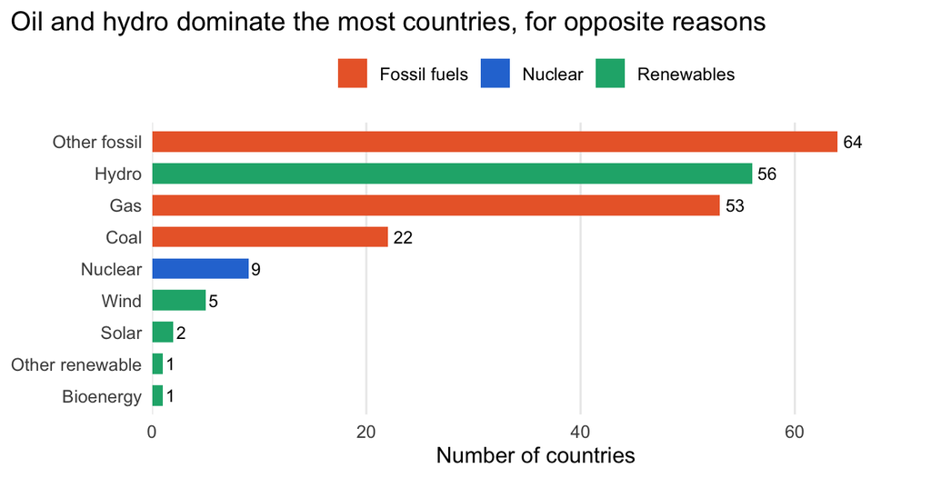

Figure 2: Countries grouped by their dominant generation source, coloured by energy group.

```r
dominant |>
  count(energy_group, source, name = "countries") |>
  mutate(source = fct_reorder(source, countries)) |>
  ggplot(aes(x = countries, y = source, fill = energy_group)) +
  geom_col(width = 0.65) +
  geom_text(aes(label = countries), hjust = -0.3, size = 3.3) +
  scale_fill_manual(values = c("Fossil fuels" = accent_2, "Renewables" = "#1baf7a",
                               "Nuclear" = accent), name = NULL) +
  scale_x_continuous(expand = expansion(mult = c(0, 0.12))) +
  labs(title = "Oil and hydro dominate the most countries, for opposite reasons",
       x = "Number of countries", y = NULL) +
  theme_p2 +
  theme(legend.position = "top", panel.grid.major.y = element_blank())
```

```r
dominant |>
  group_by(energy_group) |>
  summarise(countries = n(),
            combined_twh = round(sum(total_generation)),
            .groups = "drop") |>
  arrange(desc(countries)) |>
  kable(col.names = c("Dominant energy group", "Countries", "Their combined output (TWh)"))
```

| Dominant energy group | Countries | Their combined output (TWh) |
| --- | --- | --- |
| Fossil fuels | 139 | 26791 |
| Renewables | 65 | 3887 |
| Nuclear | 9 | 1035 |

# Conclusions

- **“Most sustainable” depends entirely on how it is measured, which is the real finding here.** By absolute renewable output the answer is **China**, at 3913 TWh, but that is only 37% of its own generation, because it also burns more coal than any other country. By share, nine countries are effectively 100% renewable, but most are small: the Central African Republic reaches 100% on 0.1 TWh, which is roughly a rounding error in China’s total.
- **Among large producers, Norway is the clearest answer**, at 99% renewable on 161 TWh, almost entirely hydro, followed by Brazil at 87% on 751 TWh. Brazil is arguably the more impressive case, since it sustains that share at nearly five times Norway’s scale.
- **The most fossil-dependent large producers are oil and gas exporters**: Iraq (98.4%), Bangladesh (97.9%) and Saudi Arabia (97.8%) all generate almost nothing from renewables.
- **Countries do group cleanly by dominant source, into 9 groups.** The two largest are telling opposites: 64 countries run mostly on *other fossil fuels*, which here means oil, and these are overwhelmingly small island and developing states that burn imported diesel; 56 run mostly on *hydro*, usually because geography handed them a river. Only 7 countries are led by wind or solar, which shows how recent those technologies still are at national scale.
- **Fossil fuels dominate in 139 of the 213 countries analysed**, and the world mix is still 57.4% fossil-fired. The countries with the greenest mixes are mostly those with the luck of a large river, not those that have transitioned away from coal.

The tidying step is what made the comparison possible: the renewable share of each country requires grouping by `energy_group`, a variable that existed only as a header spanning three columns in the source table.